# BC Elections Statitics

```r
library(infer)
library(palmerpenguins)
library(tidyverse)
library(rlang)
library(tidyverse)
```

## Part 1: Using bootstrapping on the data

```r
poll_data <- read_csv("data/angus_reid_poll.csv")
```

```r
ci_pipeline <- function(sample) {
  sample %>%
    get_confidence_interval(level = 0.95, type = "percentile")
}

set.seed(2020)
boostrap_poll <- poll_data %>%
  rep_sample_n(size = nrow(.), replace = TRUE, reps = 10000) %>%
  count(party) %>%
  mutate(stat = n / 714) %>%
  select(-n) %>%
  group_by(party) %>%
  nest() %>%
  # boostrap dist for every party
#used data to calculate estimate, when I could have calculated directly from sample
  mutate(percentile_ci = map(data, ci_pipeline)) %>%
  mutate(point_estimate = map_dbl(data, ~ mean(.x$stat))) %>%
  unnest(percentile_ci)
print(boostrap_poll)
```

```
## # A tibble: 4 x 5
## # Groups:   party [4]
##   party          data                  lower_ci upper_ci point_estimate
##   <chr>          <list>                   <dbl>    <dbl>          <dbl>
## 1 Another party  <tibble [10,000 x 2]>   0.0322   0.0644         0.0476
## 2 BC Green Party <tibble [10,000 x 2]>   0.112    0.162          0.137
## 3 BC Liberals    <tibble [10,000 x 2]>   0.293    0.361          0.328
## 4 BC NDP         <tibble [10,000 x 2]>   0.451    0.525          0.488
```

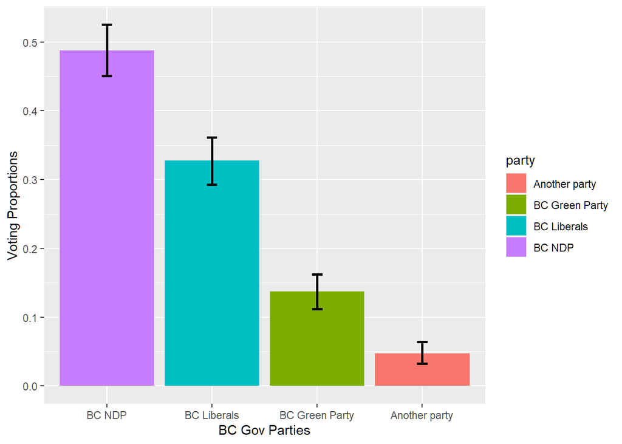

```r
# reorder to go from biggest to smallest
ggplot(boostrap_poll, aes(x = reorder(party, -point_estimate), y = point_estimate, fill = party)) +
  geom_bar(stat = "identity") +
  geom_errorbar(aes(
    ymin = lower_ci,
    ymax = upper_ci), size = 1, width = 0.1) +
  xlab("BC Gov Parties") +
  ylab("Voting Proportions")
```

## Interepations of the boostrap plot

> I am 95% confident that the true mean votes (or true population proportion) of the NDP Party is between 0.451 and 0.525, with the point estimate being 0.488.

> I am 95% confident that the true mean votes (or true population proportion) of the Liberal Party is between 0.293 and 0.361, with the point estimate being 0.328.

> I am 95% confident that the true mean votes (or true population proportion) of the Green Party is between 0.112 and 0.162, with the point estimate being 0.137.

> I am 95% confident that the true mean votes (or true population proportion) of the Another Party is between 0.0322 and 0.0644, with the point estimate being 0.0476.

## Part 2: Using CLT on the data (single sample)

```r
set.seed(2020)
proportion_poll <- poll_data %>%
group_by(party) %>%
summarize(successes = n(), stat = successes / nrow(poll_data)) %>%
mutate(StdError = sqrt(stat*(1-stat) / nrow(poll_data))) %>%
mutate(lower_95 = stat - (1.96 * StdError),
      upper_95 = stat + (1.96 * StdError))
proportion_poll
```

```
## # A tibble: 4 x 6
##   party          successes   stat StdError lower_95 upper_95
##   <chr>              <int>  <dbl>    <dbl>    <dbl>    <dbl>
## 1 Another party         34 0.0476  0.00797   0.0320   0.0632
## 2 BC Green Party        98 0.137   0.0129    0.112    0.162
## 3 BC Liberals          234 0.328   0.0176    0.293    0.362
## 4 BC NDP               348 0.487   0.0187    0.451    0.524
```

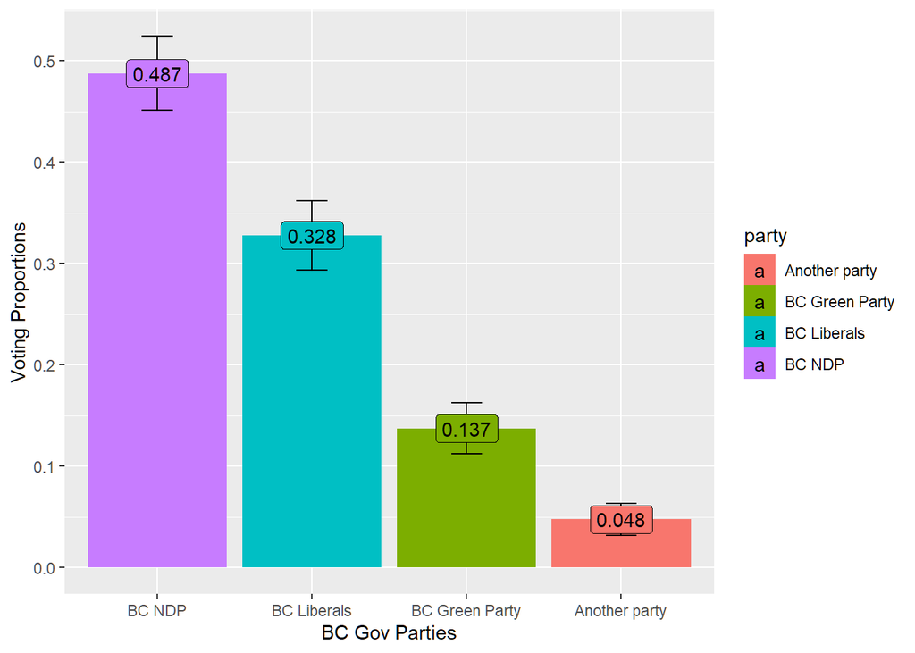

```r
proportion_poll %>% ggplot(aes(x=fct_reorder(party, stat, .desc = TRUE), y = stat, fill=party)) +
geom_bar(stat = "identity") +
geom_errorbar(data = proportion_poll, mapping = aes(ymin = lower_95, ymax = upper_95), width = 0.2) +
  xlab("BC Gov Parties") +
  ylab("Voting Proportions") +
geom_label(aes(label=round(stat,3)))
```

## Final Summary and comparisons

> Point estimate was 48.7% for NDP, 32.8% for Liberals, 13.7% for Green party, and 4.8% for the other parties. I am 95% confident that the CI is between 45% to 52.4% for NDP, 29.3% to 36.2% for Liberals, 11.2% to 16.2% for Green Party, and 3.2% to 6.3% for the other parties.

> There were no major differences from bootstrapping. This is because the sample fulfills the sample size criteria of the CLT, having enough successes/failures. In bootstrapping, many samples and calculated the PE and CIs, which should have been close to the true proportion. In Part 2, I just used one sample directly, and calculated simliar results. This is due to having a large enough sample size, allowing CLT to work.